# Status loss and participation

## Own-support +15 pp · Text outcomes · 1/4

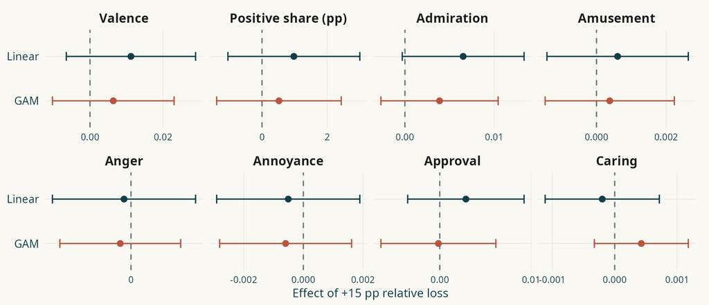

Own-support text sample: 4,809 users with pre/post comments. Linear and additive GAM; score points for emotions, percentage points for positive share. Normal 95% intervals, 200 user bootstraps.

**Earlier specification:** model fitted within supported users; not reestimated with full training. Own-support text sample: 4,809 users with pre/post comments. Linear and additive GAM; score points for emotions, percentage points for positive share. Normal 95% intervals, 200 user bootstraps.

Valence, positive share and the first six emotions have intervals spanning zero in both models.

## Own-support +15 pp · Weekly emotions · 1/2

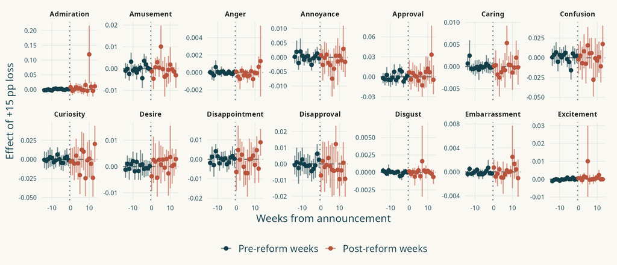

Weekly GAM on supported users with a pre mean and comments in that week: 887–1,760 users per week. All 28 labels shown over two slides. Pointwise 95% intervals, 200 user bootstraps.

**Earlier specification:** model fitted within supported users; not reestimated with full training. Weekly GAM on supported users with a pre mean and comments in that week: 887–1,760 users per week. All 28 labels shown over two slides. Pointwise 95% intervals, 200 user bootstraps.

Several labels also have pre-period deviations. Gratitude has one pre-period interval excluding zero and no post-period interval excluding zero.

## All 28 emotions by context

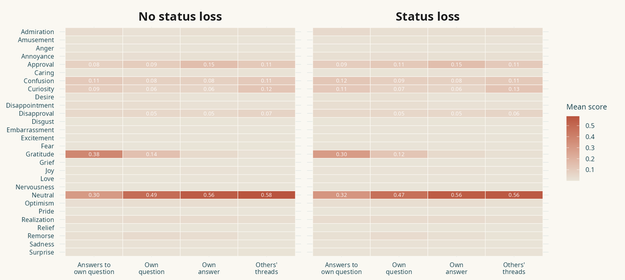

Mean pre-reform score of each GoEmotions label by thread context and group, eligible users. Numbers shown when the mean is at least 0.05.

Mean pre-reform score of each GoEmotions label by thread context and group, eligible users. Numbers shown when the mean is at least 0.05.

**Gratitude and neutral show the clearest descriptive contrasts.** These context averages do not identify comparable preceding contributions.

## Within the thanking context: all 28 emotions

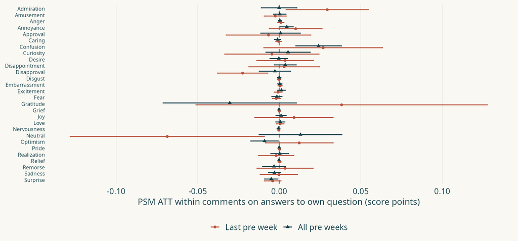

PSM ATT on user-week mean scores within comments on answers to one’s own question, eligible analysis sample (5,525 treated). Circles: last pre week; triangles: all pre weeks. Bars: 95% intervals.

PSM ATT on user-week mean scores within comments on answers to one’s own question, eligible analysis sample (5,525 treated). Circles: last pre week; triangles: all pre weeks. Bars: 95% intervals.

**No within-context emotion has an interval excluding zero under both references.** Gratitude remains imprecise; isolated label/reference findings are unadjusted for multiplicity.

## Text: +5 pp with support for this increment

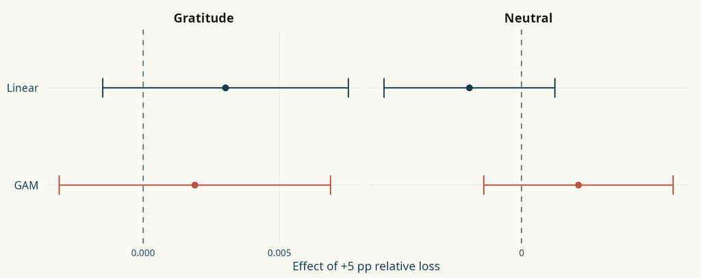

Own-support text sample: 10,011 users with pre/post comments. Gratitude and neutral; linear and additive GAM, normal 95% intervals from 200 user bootstraps.

**Earlier specification:** model fitted within supported users; not reestimated with full training. Own-support text sample: 10,011 users with pre/post comments. Gratitude and neutral; linear and additive GAM, normal 95% intervals from 200 user bootstraps.

Gratitude and neutral intervals include zero in both models. Populations change across increments; do not join these estimates into one dose curve.

## Text: +10 pp with support for this increment

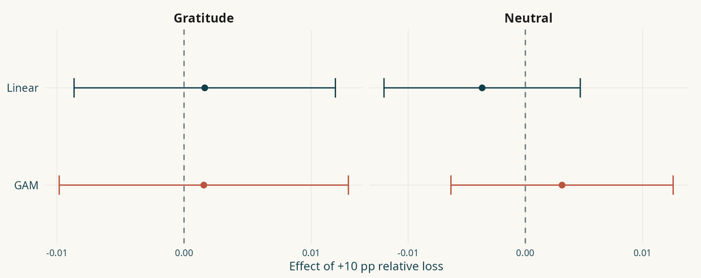

Own-support text sample: 7,191 users with pre/post comments. Gratitude and neutral; linear and additive GAM, normal 95% intervals from 200 user bootstraps.

**Earlier specification:** model fitted within supported users; not reestimated with full training. Own-support text sample: 7,191 users with pre/post comments. Gratitude and neutral; linear and additive GAM, normal 95% intervals from 200 user bootstraps.

Gratitude and neutral intervals include zero in both models. Populations change across increments; do not join these estimates into one dose curve.

## Text: +20 pp with support for this increment

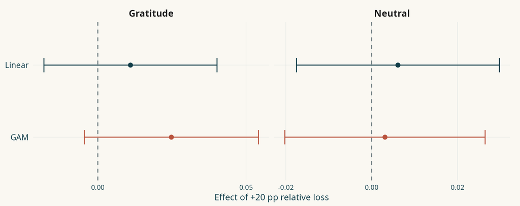

Own-support text sample: 2,817 users with pre/post comments. Gratitude and neutral; linear and additive GAM, normal 95% intervals from 200 user bootstraps.

**Earlier specification:** model fitted within supported users; not reestimated with full training. Own-support text sample: 2,817 users with pre/post comments. Gratitude and neutral; linear and additive GAM, normal 95% intervals from 200 user bootstraps.

Gratitude and neutral intervals include zero in both models. Populations change across increments; do not join these estimates into one dose curve.

## Text: +25 pp with support for this increment

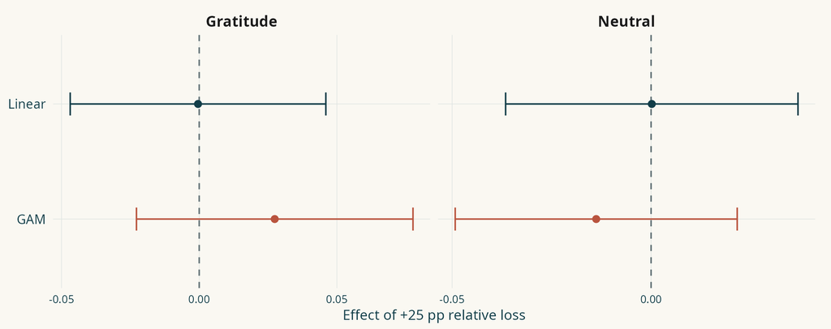

Own-support text sample: 1,519 users with pre/post comments. Gratitude and neutral; linear and additive GAM, normal 95% intervals from 200 user bootstraps.

**Earlier specification:** model fitted within supported users; not reestimated with full training. Own-support text sample: 1,519 users with pre/post comments. Gratitude and neutral; linear and additive GAM, normal 95% intervals from 200 user bootstraps.

Gratitude and neutral intervals include zero in both models. Populations change across increments; do not join these estimates into one dose curve.

## Weekly emotion-score trends · 1/7

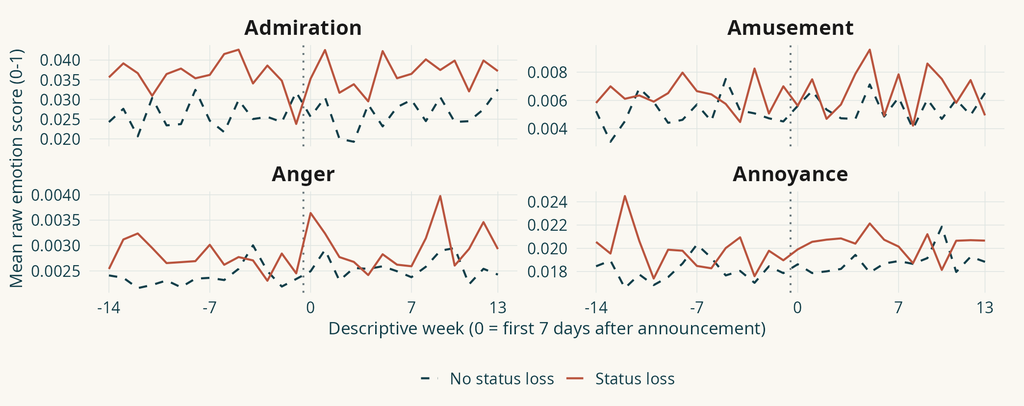

Weighted mean of observed PSM user-week emotion scores (0–1), 13,593 selected pairs. First average within user-week, then apply design weights. Week 0 = first post week; panel scales differ. Descriptive levels, not treatment effects.

Weighted mean of observed PSM user-week emotion scores (0–1), 13,593 selected pairs. First average within user-week, then apply design weights. Week 0 = first post week; panel scales differ. Descriptive levels, not treatment effects.

## Weekly emotion-score trends · 2/7

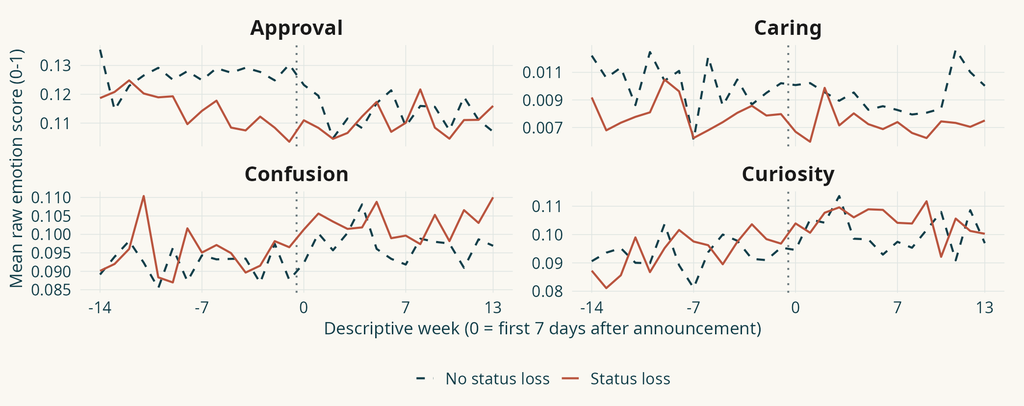

Weighted mean of observed PSM user-week emotion scores (0–1), 13,593 selected pairs. First average within user-week, then apply design weights. Week 0 = first post week; panel scales differ. Descriptive levels, not treatment effects.

Weighted mean of observed PSM user-week emotion scores (0–1), 13,593 selected pairs. First average within user-week, then apply design weights. Week 0 = first post week; panel scales differ. Descriptive levels, not treatment effects.

## Weekly emotion-score trends · 3/7

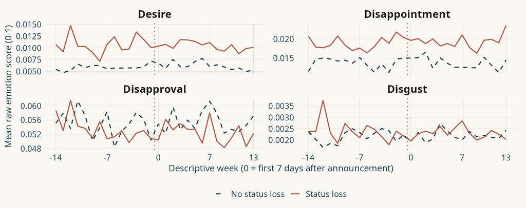

Weighted mean of observed PSM user-week emotion scores (0–1), 13,593 selected pairs. First average within user-week, then apply design weights. Week 0 = first post week; panel scales differ. Descriptive levels, not treatment effects.

Weighted mean of observed PSM user-week emotion scores (0–1), 13,593 selected pairs. First average within user-week, then apply design weights. Week 0 = first post week; panel scales differ. Descriptive levels, not treatment effects.

## Weekly emotion-score trends · 4/7

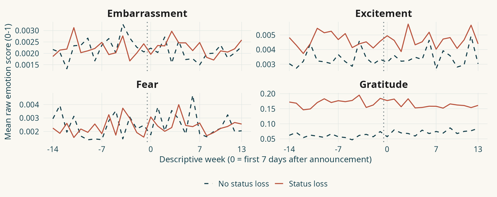

Weighted mean of observed PSM user-week emotion scores (0–1), 13,593 selected pairs. First average within user-week, then apply design weights. Week 0 = first post week; panel scales differ. Descriptive levels, not treatment effects.

Weighted mean of observed PSM user-week emotion scores (0–1), 13,593 selected pairs. First average within user-week, then apply design weights. Week 0 = first post week; panel scales differ. Descriptive levels, not treatment effects.

## Weekly emotion-score trends · 5/7

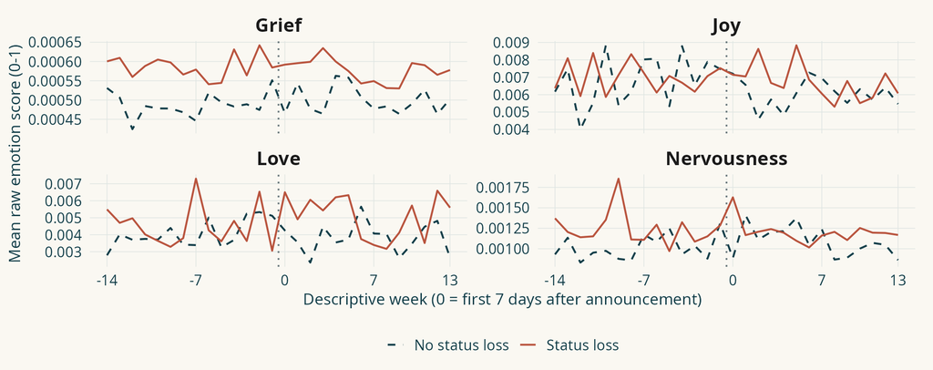

Weighted mean of observed PSM user-week emotion scores (0–1), 13,593 selected pairs. First average within user-week, then apply design weights. Week 0 = first post week; panel scales differ. Descriptive levels, not treatment effects.

Weighted mean of observed PSM user-week emotion scores (0–1), 13,593 selected pairs. First average within user-week, then apply design weights. Week 0 = first post week; panel scales differ. Descriptive levels, not treatment effects.

## Weekly emotion-score trends · 6/7

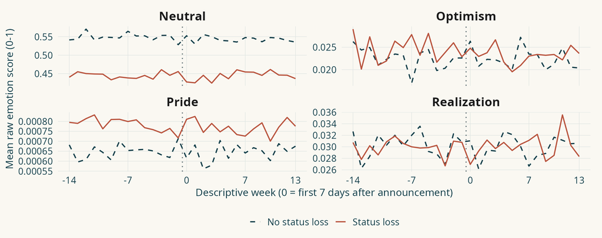

Weighted mean of observed PSM user-week emotion scores (0–1), 13,593 selected pairs. First average within user-week, then apply design weights. Week 0 = first post week; panel scales differ. Descriptive levels, not treatment effects.

Weighted mean of observed PSM user-week emotion scores (0–1), 13,593 selected pairs. First average within user-week, then apply design weights. Week 0 = first post week; panel scales differ. Descriptive levels, not treatment effects.

## Weekly emotion-score trends · 7/7

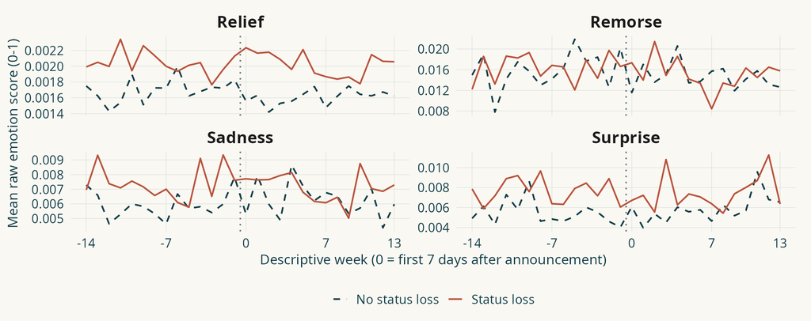

Weighted mean of observed PSM user-week emotion scores (0–1), 13,593 selected pairs. First average within user-week, then apply design weights. Week 0 = first post week; panel scales differ. Descriptive levels, not treatment effects.

Weighted mean of observed PSM user-week emotion scores (0–1), 13,593 selected pairs. First average within user-week, then apply design weights. Week 0 = first post week; panel scales differ. Descriptive levels, not treatment effects.